# Project: Movie Database Analysis

### 3. Which production companies have the highest profits?

```python
# Merge the dataframe to get stack of genres by month

df_combined = df.merge(prod_data, left_on='id', right_on='join_id', how='inner')
df_combined.head()
```

|  | id | runtime | production_companies | release_date | release_year | budget_adj | revenue_adj | profits | join_id | Company |
| --- | --- | --- | --- | --- | --- | --- | --- | --- | --- | --- |
| 0 | 135397 | 124 | Universal Studios\|Amblin Entertainment\|Legenda... | 6/9/15 | 2015 | 1.379999e+08 | 1.392446e+09 | 1.254446e+09 | 135397 | Universal Studios |
| 1 | 135397 | 124 | Universal Studios\|Amblin Entertainment\|Legenda... | 6/9/15 | 2015 | 1.379999e+08 | 1.392446e+09 | 1.254446e+09 | 135397 | Amblin Entertainment |
| 2 | 135397 | 124 | Universal Studios\|Amblin Entertainment\|Legenda... | 6/9/15 | 2015 | 1.379999e+08 | 1.392446e+09 | 1.254446e+09 | 135397 | Legendary Pictures |
| 3 | 135397 | 124 | Universal Studios\|Amblin Entertainment\|Legenda... | 6/9/15 | 2015 | 1.379999e+08 | 1.392446e+09 | 1.254446e+09 | 135397 | Fuji Television Network |
| 4 | 135397 | 124 | Universal Studios\|Amblin Entertainment\|Legenda... | 6/9/15 | 2015 | 1.379999e+08 | 1.392446e+09 | 1.254446e+09 | 135397 | Dentsu |

```python
#Sum the profits for the companies
df_clean = df_combined.groupby('Company').agg({'profits':['sum']})
df_clean.columns = ['profits_sum']
df_clean.sort_values(by='profits_sum', ascending=False)
top_20 = df_clean.sort_values(by='profits_sum', ascending=False)[:20].sum()
total = df_clean.sort_values(by='profits_sum', ascending=False).sum()
df_clean.sort_values(by='profits_sum', ascending=False)
```

| Company | profits_sum |
| --- | --- |
| Warner Bros. | 4.392299e+10 |
| Universal Pictures | 4.261918e+10 |
| Paramount Pictures | 3.810520e+10 |
| Twentieth Century Fox Film Corporation | 3.775190e+10 |
| Walt Disney Pictures | 2.555429e+10 |
| Columbia Pictures | 2.031701e+10 |
| Amblin Entertainment | 1.639077e+10 |
| New Line Cinema | 1.591263e+10 |
| Metro-Goldwyn-Mayer (MGM) | 1.344559e+10 |
| Lucasfilm | 1.308225e+10 |
| DreamWorks SKG | 1.151110e+10 |
| Columbia Pictures Corporation | 1.101265e+10 |
| Eon Productions | 1.047773e+10 |
| Touchstone Pictures | 9.737608e+09 |
| DreamWorks Animation | 8.748927e+09 |
| Heyday Films | 8.423466e+09 |
| Village Roadshow Pictures | 8.318186e+09 |
| Relativity Media | 8.142183e+09 |
| Dune Entertainment | 8.089282e+09 |
| Pixar Animation Studios | 8.010446e+09 |
| Legendary Pictures | 7.893480e+09 |
| Marvel Studios | 6.322031e+09 |
| TriStar Pictures | 6.306007e+09 |
| WingNut Films | 6.063813e+09 |
| Jerry Bruckheimer Films | 5.851598e+09 |
| Lightstorm Entertainment | 5.847474e+09 |
| United Artists | 5.315314e+09 |
| Regency Enterprises | 5.116539e+09 |
| Summit Entertainment | 5.114190e+09 |
| Silver Pictures | 4.950197e+09 |
| ... | ... |
| Vnesheconombank | -7.382104e+07 |
| HCC Media Group | -7.382104e+07 |
| Nutcracker Holdings | -7.382104e+07 |
| Open City Films | -7.532700e+07 |
| Accent Films | -7.631000e+07 |
| Cominco | -7.631000e+07 |
| Road Rebel | -7.833528e+07 |
| National Geographic Society | -7.859216e+07 |
| Paradox Entertainment | -8.091237e+07 |
| Palomar Pictures (II) | -8.111227e+07 |
| Chris Lee Productions | -8.114491e+07 |
| ScreenWest | -8.147463e+07 |
| France 2 CinÃ©ma | -8.155140e+07 |
| Crusader Entertainment | -8.263725e+07 |
| Lolita Productions | -8.278450e+07 |
| Virtual Films | -8.768115e+07 |
| Screenland Pictures | -9.518961e+07 |
| Golar Productions | -9.532863e+07 |
| Marty Katz Productions | -9.662605e+07 |
| Baldwin Entertainment Group | -9.780042e+07 |
| Carthago Films S.a.r.l. | -1.098066e+08 |
| Allied Filmmakers | -1.113766e+08 |
| The Canton Company | -1.148819e+08 |
| Dante Entertainment | -1.433424e+08 |
| Warner Bros. Pictures | -1.455555e+08 |
| Le Studio Canal+ | -1.490093e+08 |
| Blind Wink Productions | -1.551102e+08 |
| Silver Bullet Productions (II) | -1.551102e+08 |
| Franchise Pictures | -3.747935e+08 |
| Boram Entertainment Inc. | -4.139124e+08 |

3265 rows × 1 columns

```python
#percent the top 20 accounts for
(top_20/total)*100
```

```
profits_sum    36.764419
dtype: float64
```

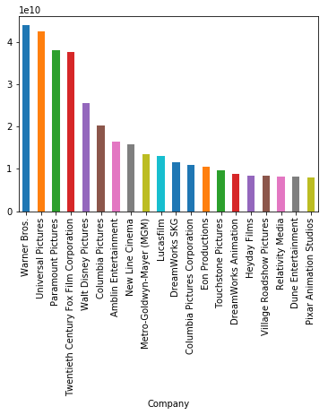

```python
#show monthly releases with profits
df_clean.profits_sum.sort_values(ascending=False)[:20].plot(kind='bar')
```

**Analysis** The top three companies that make the most money are Warner, Universal and Paramount. The top 20 companies account for 36.7% of the total profits made.

### 4. Which month is best to release a movie?

```python
#Convert release date to date time object
df['release_date']= pd.to_datetime(df['release_date'])
```

```python
#seperate out months
df['Month'] = df['release_date'].dt.month
```

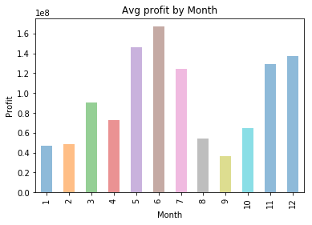

```python
#show monthly releases with profits
df.groupby('Month').mean().profits.plot(kind = "bar", title = 'Avg profit by Month', alpha = .5);

plt.xlabel('Month');
plt.ylabel('Profit');
plt.show()
```

**Analysis** It looks like there is a big spike in profit over summer, which would make sense because students are out of school and have nothing to do.

## Conclusions

**Question 1:** Which decade spent/made the most money?

**Conclusion:** It looks like the 60's had the highest averages for budget and profits, but there was a lot of fluctuation.

**Question 2:** Which prodcution companies make the most movies?

**Conclusion:** The top 3 production companies are Universal, Warner, and Paramount.

**Question 3:** Which production companies have the highest profits?

**Conclusion:** The top three companies that make the most money are Warner, Universal and Paramount.

**Question 4:** Which month is best to release a movie?

**Conclusion:** The best month is June, but it looks like the best bet would be to release a movie in the summer or during the holidays.

## Submitting your Project

```python
from subprocess import call
call(['python', '-m', 'nbconvert', 'Investigate_a_Dataset.ipynb'])
```